# plasma storage project - data analysis

Savannah Weaver

2023

# Packages

```r
if (!require("tidyverse")) install.packages("tidyverse")
```

```r
library("tidyverse") # workflow and plots
if (!require("rmdformats")) install.packages("rmdformats")
library("rmdformats") # clean html R markdown format
if (!require("emmeans")) install.packages("emmeans")
library("emmeans") # marginal means
if (!require("RColorBrewer")) install.packages("RColorBrewer")
library("RColorBrewer") # pretty colors
```

# Background and Goals

We will take our cleaned-up df from the wrangling Rmd, and make some figures and run some statistics to determine whether storage temperature and time affect the plasma osmolality of blood plasma samples.

# Load Data

```r
dat <- read_rds("./data/osml_means_clean.RDS")
```

Subset to only be push cap, because the screw cap storage was not great. :(

```r
dat_push <- dat %>%
  dplyr::filter(tube == "push")

summary(dat_push)
```

```
##     tube       storage   sample_no osmolality_mmol_kg_mean       Temperature
##  push :45   0      : 5   1:9       Min.   :313.3           None        : 5
##  screw: 0   FM     : 5   2:9       1st Qu.:323.3           Refrigerator:20
##             FT     : 5   3:9       Median :328.3           Freezer     :20
##             FV     : 5   4:9       Mean   :329.4
##             FW     : 5   5:9       3rd Qu.:334.3
##             RM     : 5             Max.   :354.7
##             (Other):15
##     Days
##  0    : 5
##  2    :10
##  3-4  :10
##  7    :10
##  28-29:10
##
##
```

Another funky thing is that for the time=0 samples, the tubes technically were not stored in the fridge or freezer. But, coding it as something different from the other samples makes it difficult (impossible?) to do any statistical comparisons across time. So, I leave the temp as “none” for figures, but for stats, I code those samples as both “Refridgerator” and “Freezer”, duplicating the time=0 points. This is the best way I could think of to achieve reasonable statistics.

Alternatives that I thought of, with their downsides:

- Code the temp for time zero pts as *either* fridge or freezer, but then you cannot compare the across time (i.e. if time 0 is coded as only fridge, then you cannot compare to the freezer storage at other pts). Coding the time zero temp as something other than fridge or freezer leads to this issue for all comparisons.
- We could create a single “temp/time” variable, and compare across individual groups. But, then we aren’t specifically measuring the effect of each of time and temp, and we’re not interested in the comparison of t2-fridge vs t7-freezer.
- calculate the CHANGE from 0 to each time point/temp and run t-tests, but this is pretty similar to just running t-tests on each sample pair individually, when then also does not account for multiple stats comparisons, so would that introduce false independence and thus statistical inflation??

# Statistics

## Marginal Means

Get the average osmolality for each time point/ temperature, and the pairwise statistical differences.

### data wrangling

```r
remove <- dat_push %>%
  dplyr::filter(Days != "0")
to_fix <- dat_push %>%
  dplyr::filter(Days == "0")
fridge_fix <- to_fix %>%
  mutate(Temperature = "Refrigerator")
freezer_fix <- to_fix %>%
  mutate(Temperature = "Freezer")
together <- remove %>%
  rbind(fridge_fix) %>%
  rbind(freezer_fix)
```

### lm

Use this lm to determine whether the effects of temperature, time, or their interaction are statistically significant.

```r
lm_interaction <- lm(data = together, osmolality_mmol_kg_mean ~ Temperature*Days)

summary(lm_interaction)
```

```
##
## Call:
## lm(formula = osmolality_mmol_kg_mean ~ Temperature * Days, data = together)
##
## Residuals:
##     Min      1Q  Median      3Q     Max
## -11.267  -3.633  -0.300   3.542  13.400
##
## Coefficients:
##                               Estimate Std. Error t value Pr(>|t|)
## (Intercept)                  3.192e+02  2.500e+00 127.702  < 2e-16 ***
## TemperatureFreezer           6.677e-15  3.535e+00   0.000 1.000000
## Days2                        4.667e+00  3.535e+00   1.320 0.194288
## Days3-4                      4.667e+00  3.535e+00   1.320 0.194288
## Days7                        1.027e+01  3.535e+00   2.904 0.005967 **
## Days28-29                    1.523e+01  3.535e+00   4.309 0.000104 ***
## TemperatureFreezer:Days2     1.533e+00  4.999e+00   0.307 0.760649
## TemperatureFreezer:Days3-4   1.533e+00  4.999e+00   0.307 0.760649
## TemperatureFreezer:Days7     7.467e+00  4.999e+00   1.494 0.143131
## TemperatureFreezer:Days28-29 1.190e+01  4.999e+00   2.380 0.022147 *
## ---
## Signif. codes:  0 '***' 0.001 '**' 0.01 '*' 0.05 '.' 0.1 ' ' 1
##
## Residual standard error: 5.589 on 40 degrees of freedom
## Multiple R-squared:  0.7254, Adjusted R-squared:  0.6637
## F-statistic: 11.74 on 9 and 40 DF,  p-value: 9.14e-09
```

```r
anova <- data.frame(anova(lm_interaction))
anova
```

```
##                  Df    Sum.Sq   Mean.Sq   F.value       Pr..F.
## Temperature       1  251.6272 251.62722  8.054792 7.095052e-03
## Days              4 2796.5533 699.13833 22.379986 9.234493e-10
## Temperature:Days  4  253.5311  63.38278  2.028934 1.087123e-01
## Residuals        40 1249.5778  31.23944        NA           NA
```

The temperature that plasma is stored at and the number of days it is stored *does* affect osmolality values, but the interaction is not significant.

Even though the interaction is not statistically significant, this is still the model structure we want to use, because we want to know whether the difference between fridge vs freezer samples changes over time.

**stats stmts for paper**: Plasma osmolality significantly differed over time (F(4, 40) = 22.38, p < 0.0001), and between being stored in the refrigerator versus freezer (F(1,40) = 8.05, p = 0.007), but there was no interaction of time and storage temperature (F(4,40) = 2.03, p = 0.1).

### check assumptions

Check linearity, normality, and equal error variance.

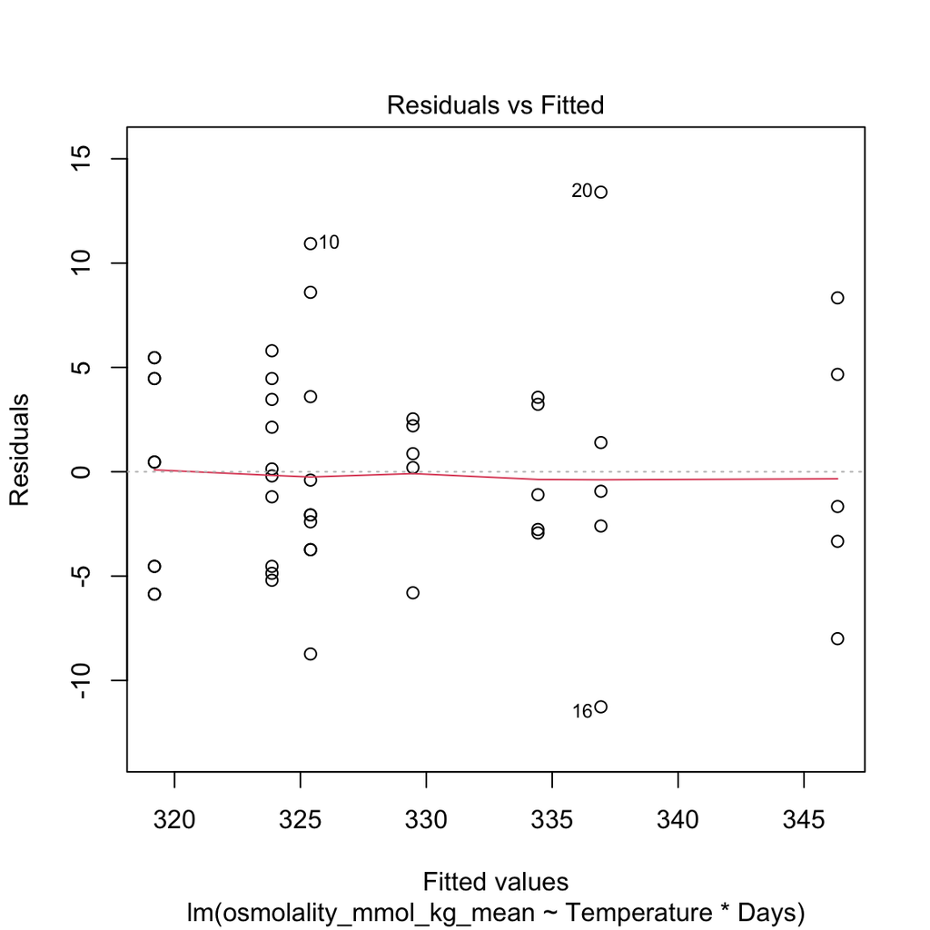

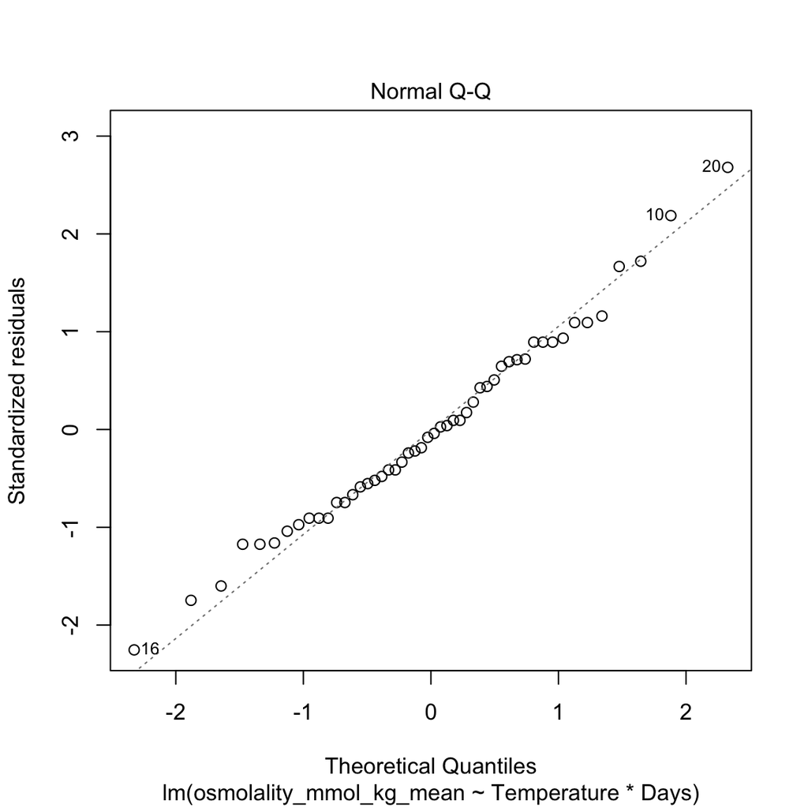

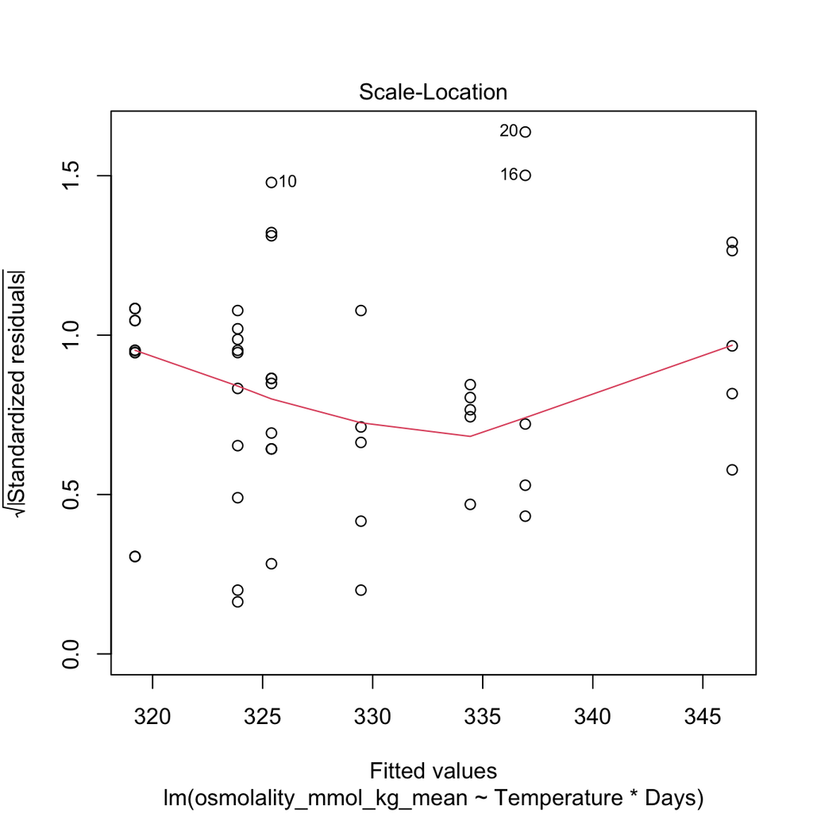

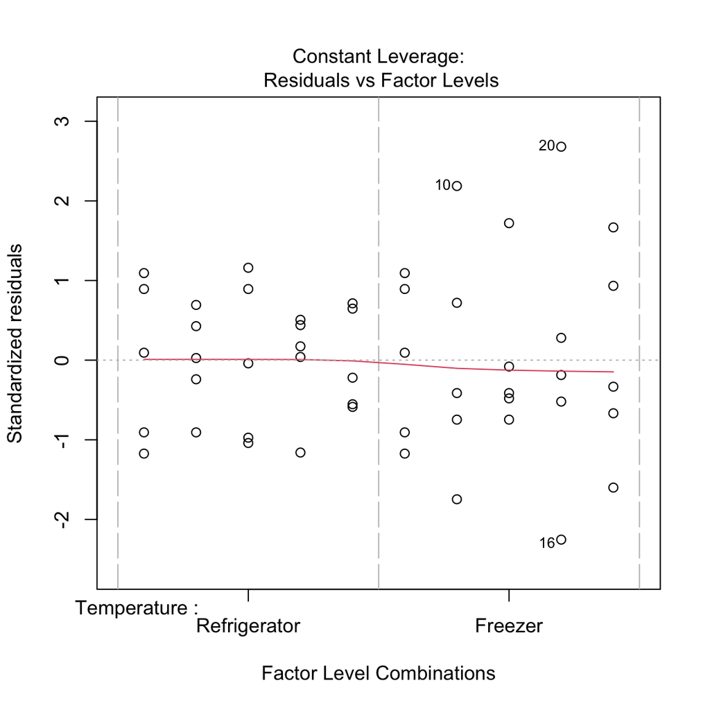

```r
plot(lm_interaction)
```

These are the most perfect LNE plots I’ve ever seen!

### emmeans

Now, get the marginal means, confidence intervals of those means, and pairwise differences between each sample group:

```r
emmeans <- data.frame(emmeans(lm_interaction, pairwise ~ Temperature | Days)$emmean)
emmeans
```

```
##     Temperature  Days   emmean       SE df lower.CL upper.CL
## 1  Refrigerator     0 319.2000 2.499578 40 314.1482 324.2518
## 2       Freezer     0 319.2000 2.499578 40 314.1482 324.2518
## 3  Refrigerator     2 323.8667 2.499578 40 318.8148 328.9185
## 4       Freezer     2 325.4000 2.499578 40 320.3482 330.4518
## 5  Refrigerator   3-4 323.8667 2.499578 40 318.8148 328.9185
## 6       Freezer   3-4 325.4000 2.499578 40 320.3482 330.4518
## 7  Refrigerator     7 329.4667 2.499578 40 324.4148 334.5185
## 8       Freezer     7 336.9333 2.499578 40 331.8815 341.9852
## 9  Refrigerator 28-29 334.4333 2.499578 40 329.3815 339.4852
## 10      Freezer 28-29 346.3333 2.499578 40 341.2815 351.3852
```

```r
temp_diffs <- data.frame(emmeans(lm_interaction, pairwise ~ Temperature | Days)$contrasts)
temp_diffs
```

```
##                 contrast  Days      estimate       SE df       t.ratio
## 1 Refrigerator - Freezer     0 -6.677080e-15 3.534937 40 -1.888882e-15
## 2 Refrigerator - Freezer     2 -1.533333e+00 3.534937 40 -4.337654e-01
## 3 Refrigerator - Freezer   3-4 -1.533333e+00 3.534937 40 -4.337654e-01
## 4 Refrigerator - Freezer     7 -7.466667e+00 3.534937 40 -2.112249e+00
## 5 Refrigerator - Freezer 28-29 -1.190000e+01 3.534937 40 -3.366397e+00
##       p.value
## 1 1.000000000
## 2 0.666789373
## 3 0.666789373
## 4 0.040957293
## 5 0.001692291
```

```r
time_diffs <- data.frame(emmeans(lm_interaction,
                                 pairwise ~ Days | Temperature)$contrasts) %>%
  dplyr::filter(substr(contrast, 1, 1) == "0")
time_diffs
```

```
##      contrast  Temperature   estimate       SE df   t.ratio      p.value
## 1       0 - 2 Refrigerator  -4.666667 3.534937 40 -1.320156 6.805024e-01
## 2   0 - (3-4) Refrigerator  -4.666667 3.534937 40 -1.320156 6.805024e-01
## 3       0 - 7 Refrigerator -10.266667 3.534937 40 -2.904342 4.457444e-02
## 4 0 - (28-29) Refrigerator -15.233333 3.534937 40 -4.309365 9.355780e-04
## 5       0 - 2      Freezer  -6.200000 3.534937 40 -1.753921 4.139395e-01
## 6   0 - (3-4)      Freezer  -6.200000 3.534937 40 -1.753921 4.139395e-01
## 7       0 - 7      Freezer -17.733333 3.534937 40 -5.016591 1.053489e-04
## 8 0 - (28-29)      Freezer -27.133333 3.534937 40 -7.675762 2.148443e-08
```

Side note… SE is usually more variable. After some investigations, it seems like getting the same SE for each comparison is pretty normal given that the SD and sample size is similar/same across our samples.

prep emmeans results for plotting… Now that we have the stats, I want to go back to only displaying one set of the t0 sample size, without a fridge/freezer label

```r
to_label <- emmeans %>%
  dplyr::filter(Days == "0") %>%
  # pick one to keep, they are the same
  dplyr::filter(Temperature == "Refrigerator") %>%
  mutate(Temperature = "None")

all_good <- emmeans %>%
  dplyr::filter(Days != "0") %>%
  rbind(to_label)
```

### pretty stats table

Get marginal mean pairwise comparison ready to be a nice results data table!

```r
time_diffs_pre <- time_diffs %>%
  rename(Constant = Temperature,
         Comparison = contrast) %>%
  mutate(Constant = paste("Stored in", Constant, sep = " "),
         Comparison = paste("Day", Comparison, sep = " "))

temp_diffs_pre <- temp_diffs %>%
  rename(Constant = Days,
         Comparison = contrast) %>%
  mutate(Constant = paste("Day", Constant, sep = " "),
         Comparison = "Stored in Refrigerator versus Freezer")

all_diffs <- time_diffs_pre %>%
  rbind(temp_diffs_pre) %>%
  mutate(estimate = round(estimate, 2),
         SE = round(SE, 2),
         t_df = paste(t.ratio = round(t.ratio, 2), " (", df, ")", sep = ""),
         p.value = round(p.value, 4)) %>%
  dplyr::select(Constant, Comparison, estimate, SE, t_df, p_value = p.value)

all_diffs
```

```
##                  Constant                            Comparison estimate   SE
## 1  Stored in Refrigerator                             Day 0 - 2    -4.67 3.53
## 2  Stored in Refrigerator                         Day 0 - (3-4)    -4.67 3.53
## 3  Stored in Refrigerator                             Day 0 - 7   -10.27 3.53
## 4  Stored in Refrigerator                       Day 0 - (28-29)   -15.23 3.53
## 5       Stored in Freezer                             Day 0 - 2    -6.20 3.53
## 6       Stored in Freezer                         Day 0 - (3-4)    -6.20 3.53
## 7       Stored in Freezer                             Day 0 - 7   -17.73 3.53
## 8       Stored in Freezer                       Day 0 - (28-29)   -27.13 3.53
## 9                   Day 0 Stored in Refrigerator versus Freezer     0.00 3.53
## 10                  Day 2 Stored in Refrigerator versus Freezer    -1.53 3.53
## 11                Day 3-4 Stored in Refrigerator versus Freezer    -1.53 3.53
## 12                  Day 7 Stored in Refrigerator versus Freezer    -7.47 3.53
## 13              Day 28-29 Stored in Refrigerator versus Freezer   -11.90 3.53
##          t_df p_value
## 1  -1.32 (40)  0.6805
## 2  -1.32 (40)  0.6805
## 3   -2.9 (40)  0.0446
## 4  -4.31 (40)  0.0009
## 5  -1.75 (40)  0.4139
## 6  -1.75 (40)  0.4139
## 7  -5.02 (40)  0.0001
## 8  -7.68 (40)  0.0000
## 9      0 (40)  1.0000
## 10 -0.43 (40)  0.6668
## 11 -0.43 (40)  0.6668
## 12 -2.11 (40)  0.0410
## 13 -3.37 (40)  0.0017
```

```r
write_csv(all_diffs, "./results/marginal_means.csv")
```

## Variation Among Samples of the Same Group

would be cool to Quantify the difference in spread for samples of the same “treatment” group. It looks like variability increases over time. But, the internet says that stats to test this are very shaky, so idk if it’s worthwhile to add this.

# Figure

## Pretty Stuff

```r
theme_set(theme_classic() +
            theme(text = element_text(color = "black",
                                               family = "sans",
                                               size = 12),
                           axis.text = element_text(color = "black",
                                                    family = "sans",
                                                    size = 8),
                           legend.text = element_text(color = "black",
                                                      family = "sans",
                                                      size = 8),
                           legend.text.align = 0,
                           legend.position = "bottom"
                           ))

my_colors <- brewer.pal(8, "Dark2")[c(1,2,3)]
```

## Means

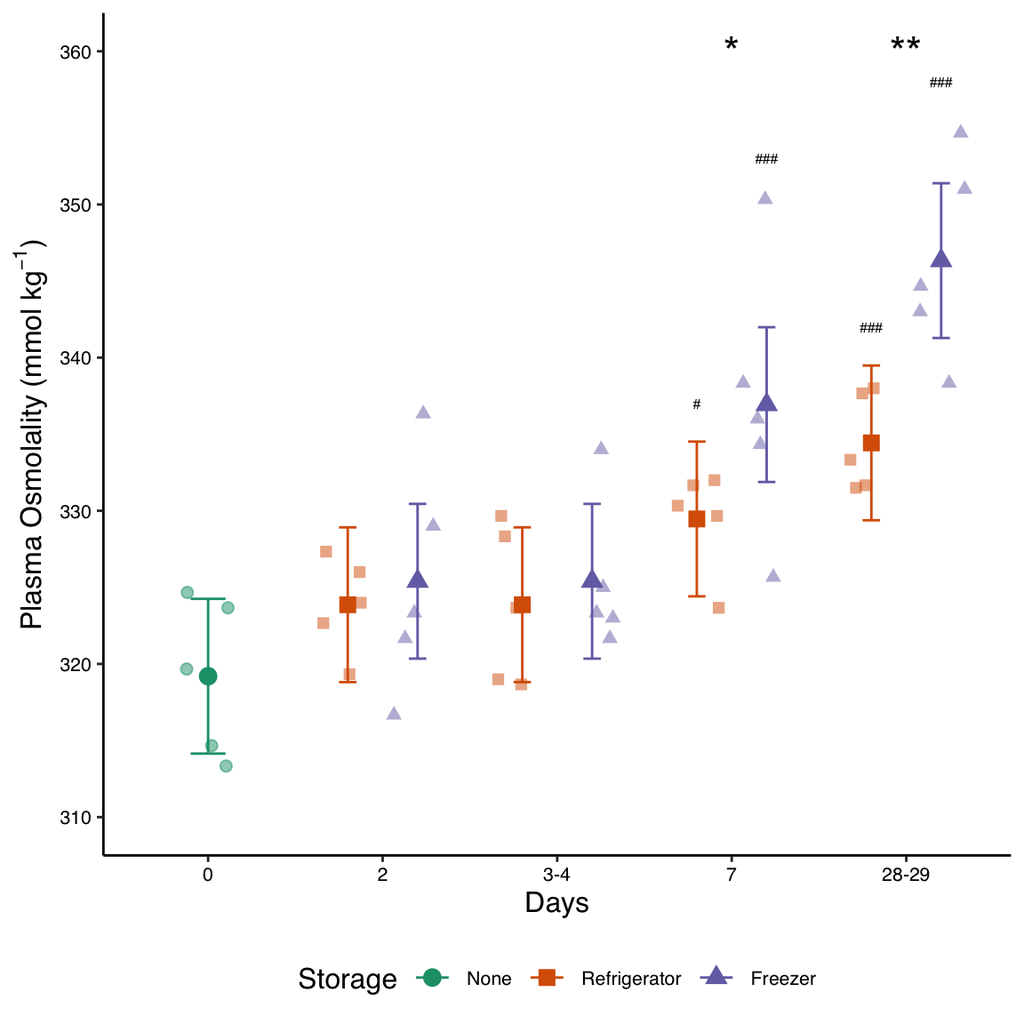

```r
ggplot() +
  geom_jitter(data = dat_push,
             aes(x = Days,
                 y = osmolality_mmol_kg_mean,
                 color = Temperature,
                 shape = Temperature),
             position = position_jitterdodge(jitter.height = 0,
                                             jitter.width = 0.7,
                                             dodge.width = 0.8),
             alpha = 0.5,
             size = 2) +
  geom_point(data = all_good,
             aes(x = Days,
                 y = emmean,
                 shape = Temperature,
                 color = Temperature,
                 ),
             position = position_dodge(width = 0.8),
             alpha = 1,
             size = 3) +
  geom_errorbar(data = all_good,
                aes(x = Days,
                    y = emmean,
                    ymin = lower.CL,
                    ymax = upper.CL,
                 color = Temperature),
             position = position_dodge(width = 0.8),
                width = .2) +

  # stats between storage methods
  annotate(geom = "text", x = 4, y = 360, label = "*", size = 6) +
  annotate(geom = "text", x = 5, y = 360, label = "**", size = 6) +

  # stats over time for REFRIDGE
  annotate(geom = "text", x = 3.8, y = 337, label = "#", size = 2) +
  annotate(geom = "text", x = 4.8, y = 342, label = "###", size = 2) +

  # stats over time for FREEZER
  annotate(geom = "text", x = 4.2, y = 353, label = "###", size = 2) +
  annotate(geom = "text", x = 5.2, y = 358, label = "###", size = 2) +

  scale_color_manual(name = "Storage", values = my_colors) +
  scale_shape_manual(name = "Storage", values = c(19, 15, 17)) +
  scale_y_continuous(limits = c(310, 360),
                     name = bquote('Plasma Osmolality (mmol '*kg^-1*')')) -> osml_values_plot
osml_values_plot
```

Figure legend: Plasma osmolality values change based on how long blood plasma samples are stored and whether they are stored in the refridgerator versus freezer. Large points represent marginal means ± 95% confidence intervals. Small points represent samples. * denotes significant differences between refrigerator versus freezer storage at a given time point. # denotes significant differences between time points for a given storage temperature. For both symbols, * p < 0.05, ** p < 0.01, *** p < 0.001.

## Export

```r
ggsave(filename = "storage_effects.pdf",
       plot = osml_values_plot,
       path = "./results",
       device = "pdf",
       dpi = 600,
       units = "mm",
       width = 160, height = 100
       )
```